# **Lab Assignment 3** Foundations of Deep Learning

## Assignment Metadata

- Author name:BALBIR SINGH
- ASU ID:1233870107
- File creation date:02/12/2025

### You must use this provided framework as-is and follow all the directions stated in there:

- Do NOT edit or otherwise change any part of this framework except the cells you have been instructed to code.
- You must NOT import any additional python packages to complete this assignment

### Note that, points will be deducted for notebooks that:

- do not follow the saving guidelines/naming convention
- do not compile/run
- do not follow all the instructions in the framework
- are incomplete
- have logical errors
- don’t result in the expected output

## Exercise 1 (Gradient Descent)

- In this assignment, you will first use the gradient descent algorithm to find the optimal value of w1 which minimizes the given lost function (Steps 1.1 through 1.5). You will earn 5% points for each step and 25% in total.
- You will run the algorithm for 4 different scenarios, each with a different value of alpha. For each scenario, you will log the responses in the last cell of this notebook (Step 1.6). You will earn 5% points for each scenario and 20% in total.

```python
# DO NOT edit this cell!
# You must use this lost function and its derivative as-is

# lost at particular value of w1
def calc_J(w1):
    return (5.5*w1*w1 - 1463*w1 + 100812.5)

# slope at particular value of w1
def calc_dJ_dw1(w1):
    return (11*w1 - 1463)
```

```python
# First, complete coding Steps 1.1 through 1.5 in this cell.
# Then, run this cell for each of the four scenarios below,
# and log your responses for each scenario run in the next cell (Step 1.6)
alpha=0.08; niterations = 25; w1 = 60 # Scenario 1
# alpha=0.05; niterations = 25; w1 = 60 # Scenario 2
# alpha=0.15; niterations = 25; w1 = 60 # Scenario 3
# alpha=0.19; niterations = 25; w1 = 60 # Scenario 4

# Function to run gradient descent for different scenarios
import pandas as pd

def run_gradient_descent(alpha, niterations, w1):
    results = []

    # Step 1.1: Calculate initial cost function value
    J = 5.5 * w1**2 - 1463 * w1 + 100812.5

    # Step 1.2: Store initial values
    results.append((round(w1, 2), round(J, 2)))

    # Run gradient descent for niterations
    for i in range(niterations):
        # Step 1.3: Update w1 using gradient descent
        w1 = w1 - alpha * (11 * w1 - 1463)

        # Step 1.4: Compute new J
        J = 5.5 * w1**2 - 1463 * w1 + 100812.5

        # Step 1.5: Store results
        results.append((round(w1, 2), round(J, 2)))

    return results

# Running all four scenarios
scenarios = {
    "Scenario 1 (alpha=0.08)": run_gradient_descent(0.08, 25, 60),
    "Scenario 2 (alpha=0.05)": run_gradient_descent(0.05, 25, 60),
    "Scenario 3 (alpha=0.15)": run_gradient_descent(0.15, 25, 60),
    "Scenario 4 (alpha=0.19)": run_gradient_descent(0.19, 25, 60),
}

# Displaying results
for scenario, data in scenarios.items():
    df_results = pd.DataFrame(data, columns=["w1", "J"])
    print(f"\nResults for {scenario}:")
    print(df_results)
```

```
Results for Scenario 1 (alpha=0.08):
        w1         J
0    60.00  32832.50
1   124.24   3945.06
2   131.95   3529.08
3   132.87   3523.09
4   132.98   3523.00
5   133.00   3523.00
6   133.00   3523.00
7   133.00   3523.00
8   133.00   3523.00
9   133.00   3523.00
10  133.00   3523.00
11  133.00   3523.00
12  133.00   3523.00
```

[output cut: 100 more lines]

# Step 1.6: for each Scenario, answer the following questions based on the output (20%)

- Type your answers below for each question

# Scenario 1 (alpha=0.08; niterations = 25; w1 = 60):

- Did the cost steadily decrease as training progressed?

  Yes, the cost 𝐽 steadily decreased until it reached a stable value.
- Did the gradient descent algorithm converge?

  Yes, it converged around iteration 5 when J=3523.00
- What is the minimum lost?

  3523.00
- What is the optimal value of w1?

  133.00
- In how many iterations did gradient descent converge (at which row # in the output)?

  5 iterations

# Scenario 2 (alpha=0.05; niterations = 25; w1 = 60):

- Did the cost steadily decrease as training progressed?

  Yes, it decreased smoothly and reached a stable value.
- Did the gradient descent algorithm converge?

  Yes it converged around iteration 13 when J= 3523.00
- What is the minimum lost?

  3523.00
- What is the optimal value of w1?

  133.00
- In how many iterations did gradient descent converge (at which row # in the output)?

  13 iterations

# Scenario 3 (alpha=0.15; niterations = 25; w1 = 60):

- Did the cost steadily decrease as training progressed?

  Yes, although it fluctuated more initially before stabilizing.
- Did the gradient descent algorithm converge?

  Yes, it converged around iteration 19 when J =3523.00
- What is the minimum lost?

  3523.00
- What is the optimal value of w1?

  133.00
- In how many iterations did gradient descent converge (at which row # in the output)?

  19 iterations

# Scenario 4 (alpha=0.19; niterations = 25; w1 = 60):

- Did the cost steadily decrease as training progressed?

  No, the cost fluctuated wildly and started increasing exponentially.
- Did the gradient descent algorithm converge?

  No, the algorithm diverged as the learning rate was too high
- What is the minimum lost?

  The loss did not minimize; instead, it exploded to over 2 million
- What is the optimal value of w1?

  No optimal value was found since the algorithm diverged.
- In how many iterations did gradient descent converge (at which row # in the output)?

  It did not converge.

## Exercise 2 (Single Neuron)

### Then, you will apply deep learning thinking in modeling a single neuron to build logistic regression and linear regression models. You need also to Apply the idea of vectorization to efficiently train your models and implement gradient descent from scratch (using multiple iterations of the forward pass, backward propagation, and gradient descent steps) to minimize the loss functions and determine model parameters.

### Specifically, there are two parts in this assignment:

- In the first part, you will train a logistic regression model using the breast cancer data set. This part has 7 parts (2.1.1 through 2.1.7) that you will need to code (see framework for more details).
- In the second part, you will train a linear regression model using the diabetes data set. This part has 7 parts (2.2.1 through 2.2.7) that you will need to code (see framework for more details).

```python
### DO NOT EDIT THIS CELL!!!
### DO NOT IMPORT ANY ADDITIONAL PACKAGES

import numpy as np
import scipy
from sklearn import metrics
import matplotlib.pyplot as plt
%matplotlib inline
```

### PART 1

- Logistic Regression for Binary Classification using the breast cancer dataset
- We aren't going to preprocess data or split into train/test since the focus here is purely on the gradient descent algorithm
- NOTE: YOU WILL ONLY EDIT ONE CELL FOR PART-1 (SEE BELOW) (5% for each step, but 25% in total)

```python
### DO NOT EDIT THIS CELL!!!

# read the breast cancer dataset from sklearn
from sklearn.datasets import load_breast_cancer

dataset = load_breast_cancer()

# feature matrix X: mxn
X = dataset.data
print ("X: ", X.shape)

# target vector y: mx1
y = dataset.target
y = y.reshape(y.shape[0], 1)
print ("y: ", y.shape)

# number of samples: m
m = X.shape[0]
print ("m: ", m)

# number of features: n
n = X.shape[1]
features = dataset.feature_names
print ("n: ",n)
print ("features: ", features)
```

```
X:  (569, 30)
y:  (569, 1)
m:  569
n:  30
features:  ['mean radius' 'mean texture' 'mean perimeter' 'mean area'
 'mean smoothness' 'mean compactness' 'mean concavity'
 'mean concave points' 'mean symmetry' 'mean fractal dimension'
 'radius error' 'texture error' 'perimeter error' 'area error'
 'smoothness error' 'compactness error' 'concavity error'
 'concave points error' 'symmetry error' 'fractal dimension error'
 'worst radius' 'worst texture' 'worst perimeter' 'worst area'
 'worst smoothness' 'worst compactness' 'worst concavity'
 'worst concave points' 'worst symmetry' 'worst fractal dimension']
```

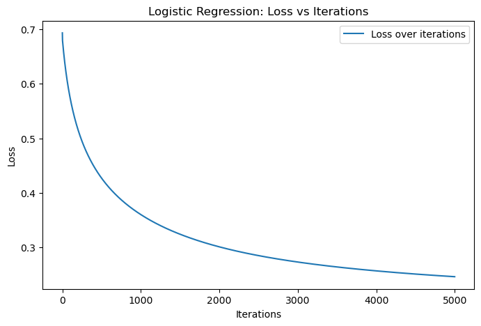

```
Final Training Accuracy: 0.9191564147627417
```

```python
# === THIS IS THE ONLY CELL YOU MUST EDIT FOR PART-1 ===
# Import necessary libraries
import numpy as np
import matplotlib.pyplot as plt
from sklearn import metrics
from sklearn.datasets import load_breast_cancer

# Train the logistic regression model

# (2.1.1) Initialize hyperparameters
nepochs = 5000  # Number of iterations
alpha = 2.5e-6  # Learning rate

# (2.1.1) Initialize model parameters w and b
w = np.zeros((n, 1))  # Initialize weights to zero
b = 0  # Initialize bias to zero

# This list will collect loss for each iteration
costs = []

# Sigmoid function
def sigmoid(z):
    return 1 / (1 + np.exp(-z))

# (2.1.1) Training loop for nepochs
for epoch in range(nepochs):
    # (2.1.2) Forward pass: Compute z and apply sigmoid activation
    z = np.dot(X, w) + b
    y_hat = sigmoid(z)

    # Compute loss using Binary Cross-Entropy
    loss = -np.mean(y * np.log(y_hat + 1e-15) + (1 - y) * np.log(1 - y_hat + 1e-15))
    costs.append(loss)

    # (2.1.3) Backward propagation: Compute gradients
    dw = np.dot(X.T, (y_hat - y)) / m
    db = np.sum(y_hat - y) / m

    # (2.1.4) Gradient Descent Update
    w -= alpha * dw
    b -= alpha * db

# (2.1.6) Compute final accuracy
y_pred = np.round(sigmoid(np.dot(X, w) + b))  # Convert probabilities to binary labels
accuracy = metrics.accuracy_score(y, y_pred)

# (2.1.7) Plot loss curve
plt.figure(figsize=(8, 5))
plt.plot(costs, label="Loss over iterations")
plt.xlabel("Iterations")
plt.ylabel("Loss")
plt.title("Logistic Regression: Loss vs Iterations")
plt.legend()
plt.show()

# Print final accuracy
print("Final Training Accuracy:", accuracy)
```

```python
### DO NOT EDIT THIS CELL!!!

# compare results from your implementation to that of SGDClassifier
# your accuracy score above should match (or be very close to) what you get from here

nepochs = 5000
alpha = 2.5e-6
y = y.reshape(y.shape[0],) # to avoid warning

from sklearn.linear_model import SGDClassifier
clf = SGDClassifier(loss='log_loss', # loss function for logistic regression
                    penalty=None, alpha=0, # no regularization
                    max_iter=nepochs, tol=None, # stop based only on nepochs
                    shuffle=False, random_state=0, # don't shuffle, use random state to replicate results
                    learning_rate='constant', eta0=alpha) # constant learning rate of alpha
clf.fit(X,y)
print (round(clf.score(X,y),2))
```

```
0.92
```

### Part 2

- Linear Regression using the diabetes dataset
- We aren't going to preprocess data or split into train/test since the focus here is purely on the gradient descent algorithm
- NOTE: YOU WILL ONLY EDIT ONE CELL FOR PART-2 (SEE BELOW) (5% for each step, but 25% in total)

```python
### DO NOT EDIT THIS CELL!!!

# read the diabetes dataset from sklearn
from sklearn.datasets import load_diabetes

dataset = load_diabetes()

# feature matrix X: mxn
X = dataset.data
print ("X: ", X.shape)

# target vector y: mx1
y = dataset.target
y = y.reshape(y.shape[0], 1)
print ("y: ", y.shape)

# number of samples: m
m = X.shape[0]
print ("m: ", m)

# number of features: n
n = X.shape[1]
features = dataset.feature_names
print ("n: ",n)
print ("features: ", features)
```

```
X:  (442, 10)
y:  (442, 1)
m:  442
n:  10
features:  ['age', 'sex', 'bmi', 'bp', 's1', 's2', 's3', 's4', 's5', 's6']
```

```
Final Mean Squared Error (MSE): 2878.2652308679494
Final R² Score: 0.5146170151856408
```

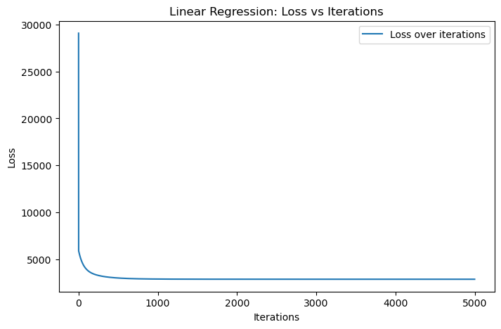

```python
# === THIS IS THE ONLY CELL YOU MUST EDIT FOR PART-2 ===

# Train the linear regression model

# (2.2.1) Initialize hyperparameters
nepochs = 5000  # Number of iterations
alpha = 0.5  # Learning rate

# (2.2.1) Initialize model parameters w and b
w = np.zeros((n, 1))  # Initialize weights to zero
b = 0  # Initialize bias to zero

# This list will collect loss for each iteration
costs = []

# (2.2.1) Training loop for nepochs
for epoch in range(nepochs):
    # (2.2.2) Forward pass: Compute predictions y_hat
    y_hat = np.dot(X, w) + b

    # Compute Mean Squared Error (MSE) loss
    loss = np.mean((y_hat - y) ** 2)
    costs.append(loss)

    # (2.2.3) Backward propagation: Compute gradients
    dw = (2 / m) * np.dot(X.T, (y_hat - y))
    db = (2 / m) * np.sum(y_hat - y)

    # (2.2.4) Gradient Descent Update
    w -= alpha * dw
    b -= alpha * db

# (2.2.6) Compute final MSE and R² score
from sklearn import metrics

y_pred = np.dot(X, w) + b
mse = metrics.mean_squared_error(y, y_pred)
r2_score = metrics.r2_score(y, y_pred)

# Print final evaluation metrics
print("Final Mean Squared Error (MSE):", mse)
print("Final R² Score:", r2_score)

# (2.2.7) Plot loss curve
import matplotlib.pyplot as plt

plt.figure(figsize=(8, 5))
plt.plot(costs, label="Loss over iterations")
plt.xlabel("Iterations")
plt.ylabel("Loss")
plt.title("Linear Regression: Loss vs Iterations")
plt.legend()
plt.show()
```

```python
### DO NOT EDIT THIS CELL!!!

# compare results from our implementation to that of SGDRegressor
# your mse and r2 score above should match (or be very close to) what you get from here

nepochs = 5000
alpha = 2.5e-6
y = y.reshape(y.shape[0],) # to avoid warning

from sklearn.linear_model import SGDRegressor
clf = SGDRegressor(loss='squared_error', # mse for linear regression
                    penalty=None, alpha=0, # no regularization
                    max_iter=nepochs, tol=None, # stop based on only on nepochs
                    shuffle=False, random_state=0, # don't shuffle, use random state to replicate results
                    learning_rate='constant', eta0=alpha) # constant learning rate of alpha
clf.fit(X,y)
yhat = clf.predict(X)
print (round(metrics.mean_squared_error(y, yhat),2))
print (round(clf.score(X,y),2))
```

```
5723.38
0.03
```

## Acknowledgment

- I have used ChatGPT as a GenAI tool to assist in understanding and implementing gradient descent for logistic and linear regression. The tool provided clarifications on concepts, debugging help, and optimized code structure while ensuring that the final implementation adhered to the assignment framework.

I have completed the assignment independently and have not collaborated with anyone else in this task.

```python
# HTML rendering

!pip install jupyter
!pip install nbconvert
!jupyter nbconvert "LA3_Singh_Balbir.ipynb" --to html
```

```
[NbConvertApp] Converting notebook LA3_Singh_Balbir.ipynb to html
[NbConvertApp] WARNING | Alternative text is missing on 2 image(s).
[NbConvertApp] Writing 415444 bytes to LA3_Singh_Balbir.html
```